# Om at skrive kode fra formler

Ikke så sjældent, skal vi lave et program der baseres på en formel, og skive noget kode som implementerer formlen, på de data der er tilgængelige for programmet.

Fromlen er oftest en matematisk formel.  
Vi skal kigge på at bryde formler ned i dele, og sætte dem sammen igen i et program.

[figure not shown]

Vi skal bruge modulet `math`

```python
import math
```

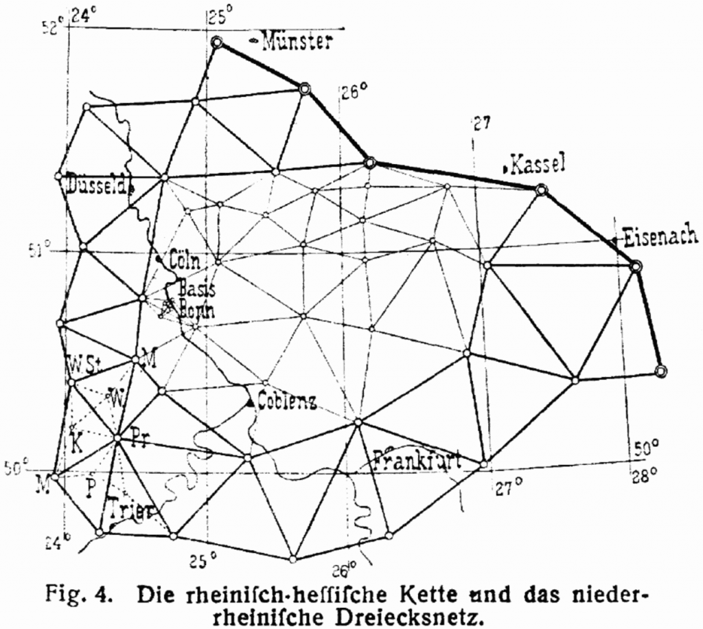

## Symboler til kode

*4 hurtige...*

| Matematik | Python |
| --- | --- |
| $ \pi $ | `math.pi` |
| $ \sqrt{x} $ | `math.sqrt(x)` |
| $ x^2 $ | `x**2` |
| $ x^n $ | `x**n` |

### $\pi$ (Pi)

$ \pi$ har jo noget at gøre med cirklers omkreds osv.

En cirkel med radius 10 (mm), har omkreds $$ 10 \cdot \pi = 31,4 $$

I Python bruger vi konstanten `pi`, fra modulet `math`.

```python
math.pi
```

```
3.141592653589793
```

```python
10 * math.pi
```

```
31.41592653589793
```

Formlen for arealet af en cirkel er $$ A_{cirkel} = \pi \cdot r^2 $$

f.eks hvis radius r = 5
$$ \pi \cdot 5^2 = 78,54 $$

```python
math.pi * 5**2
```

```
78.53981633974483
```

I øvrigt kan en kugles areal ud regnes med formlen $$ A_{kugle} = 4 \cdot \pi \cdot r^2 $$ i python bliver det:

```python
# hvis radius = 2
r = 2
4 * math.pi * r ** 2
```

```
50.26548245743669
```

Læs mere om kugler på https://da.wikipedia.org/wiki/Kugle

### Det væsentlige er at *oversætte* fra formel til kode!

$$ A_{kugle} = 4 \cdot \pi \cdot r^2 $$

I kugle-eksemplet brugte jeg en varibel `r` fordi den var i formlen. Det kunne også være at den var konstant i det aktuelle program.  
Men, mere sandsynlig, vil jeg gerne udregne arealer af flere kugler med forskellig *radius*, så jeg laver en funktion:

```python
def A_kugle(r):
    return 4 * math.pi * r ** 2

print(A_kugle(5))
```

```
314.1592653589793
```

Et lidt mere indviklet eksempel

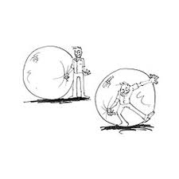

### En kugles rumfang (volumen).

*Egentlig er det lige meget med hvilke fomler det er!*  
*Bare vi kigger på at oversætte matematik til kode (i python)*

$$ V_{kugle} = \frac{4}{3} \cdot \pi \cdot r^3 $$

Nogen gange dropper man gange-tegnene i formlen (fordi de er indforståede): $ V_{kugle} = \frac{4}{3} \pi r^3 $

$$ V_{kugle} = \frac{4}{3} \cdot \pi \cdot r^3 $$

```python
def V_kugle(r):
    return 4/3 * math.pi * r**3

V_kugle(5)
```

```
523.5987755982989
```

Et endnu værre eksempel

### Breregn *radius* når vi kender *rumfanget*

$$ r_{kugle} = \left(V_{kugle} \cdot \frac{3}{4 \cdot \pi} \right)^\frac{1}{3} $$

Faktisk er det *3. rod af ...* altså $r_{kugle} = \sqrt[3]{\left(V_{kugle} \cdot \frac{3}{4 \cdot \pi} \right)} $ men den findes ikke indbygget i pythons `math`, så vi laver et trick med at opløfte i $1/3$ potens, som er det samme :-)

$$ r_{kugle} = \left(V_{kugle} \cdot \frac{3}{4 \cdot \pi} \right)^\frac{1}{3} $$

```python
def r_kugle(v):
    return v * 3 / 4 * math.pi ** 1 / 3

r_kugle(1000)
```

```
785.3981633974482
```

785 er en lidt stor radius for et rumfang på 1000!

Vi skal sørge for at bruge parenseter!

Nå man læser en formel, er der lige som nogen implicitte parentser, som vi skal sørge for at lave selv, når man omsætter formeln til programkode.

Især hvis:

- der står flere led under en brøkstreg
- potenser af noget der består af flere led

$$ r_{kugle} = \left(V_{kugle} \cdot \frac{3}{(4 \cdot \pi)} \right)^{\left(\frac{1}{3}\right)} $$

```python
def r_kugle(v):
    return (v * 3 / (4 * math.pi)) ** (1 / 3)

r_kugle(1000)
```

```
6.203504908994
```

Er det ikke rimeligt realistisk at der kan være en liter mælk (1000 ml), i en kugle med en *radius* på 6.2 cm? Husk radius er fra kant til centrum, så diameteren, tværs over kuglen (kant til kant), er ca 12.4 cm...

Hellere for mange parentereser, end for få

$$ r_{kugle} = \left(V_{kugle} \cdot \left(\frac{3}{(4 \cdot \pi)} \right) \right)^{\left(\frac{1}{3}\right)} $$

```python
def r_kugle(v):
    return (v * (3 / (4 * math.pi))) ** (1 / 3)

r_kugle(1000)
```

```
6.203504908994
```

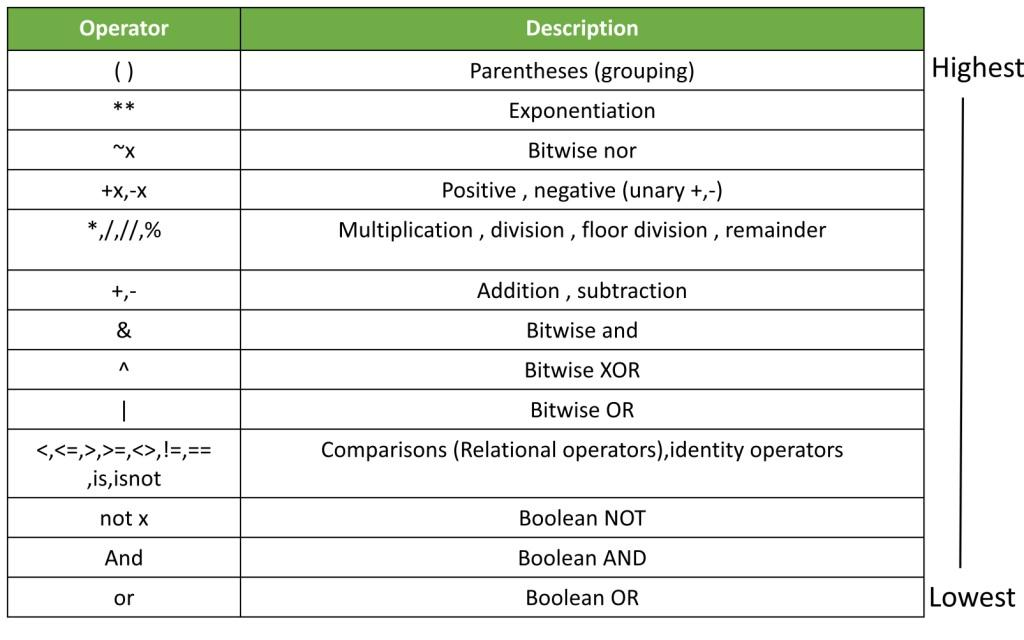

Se https://qissba.com/operators-precedence-in-python/

## Matematik med gentagelser

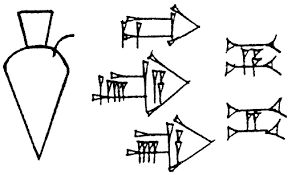

Man kan godt beskrive visse typer af gentagelser på strukturerede data, som lister, med matematiske formler. Den slags formler kommer i til at møde i data-engeneering og data-analysis, derfor denne lille introduktion :-)

Vi skal kigge på symbolerne $ \Sigma $ (og måske $ \Pi $)

Vi kender fra python at vi kan have en liste, f.eks `x = [...]`.  
I python ville vi refere til at elementerne i listen med indexerings "firkant-parenteserne",  
f.eks. værdien på plads 2 ( det 3. for vi starte på 0) med `x[2]`  
Vi siger at `x` har `n` elementer, og indekserer med variablen `i`.

```python
x = [5,8,9,2]
n = len(x)
for i in range(n):
    print(f"{i}. element i x er: {x[i]}")
```

```
0. element i x er: 5
1. element i x er: 8
2. element i x er: 9
3. element i x er: 2
```

Lidt mere besværligt end vi plejer at gøre med python og lister, men for lige at være sikker på at have notationen med...

### Sum $ \Sigma $

Nu vil jeg gerne beregne summen af tallene i listen `x`, så jeg *kunne* bare skrive `sum(x)`, men jeg vil jo gerne vise noget mere med det...

```python
resultat = 0
for i in range(n):
    resultat += x[i]

print(x)
print(resultat)
```

```
[5, 8, 9, 2]
24
```

Summen af tallene i `x`, defineres matematisk med formlen:

$$ \displaystyle\sum_{i=0}^{n-1} x_i $$

Nogen gange i kort form: $ \sum_{i=0}^{n-1} x_i $

Nogen gange skrives det mere ud som:

$$ \displaystyle\sum_{i=0}^{n-1} x_i = x_0 + x_1 + ... + x_3 $$

Med listen `x` ([5, 8, 9, 2]) vil det sige:

$$ \displaystyle\sum_{i=0}^{n-1} x_i = x_0 + x_1 + x_2 + x_3 = 5 + 8 + 9 + 2 = 24 $$

Med andre ord, $ \sum_{i=0}^{n-1} x_i $ betyder at man tager alle elementer i x ($x_i$) og lægger sammen!  
Hvor `i` starter på 0 og går op til `n-1`.  
Da `n` er længden af `x`, så da indekset starter på 0, er det sidste indeks én før længden, så at sige.

### Wow wow wow, wait-a-minute

$$ \displaystyle\sum_{i=0}^{n-1} x_i = x_0 + x_1 + ... + x_3 = 5 + 8 + 9 + 2 = 24 $$

er det samme som denne python kode:

```python
resultat = 0
for i in range(n):
    resultat += x[i]

print(x)
print(resultat)
```

```
[5, 8, 9, 2]
24
```

### Gennemsnit af `x`

I matematik notation kan man sommetider skrive gennemsnittet af x med symbolet $ \overline{x} $,  
men hvordan defineres og beregnes det?

Lidt mere populært kan sige gennemsnittet af en liste er:

```
summen af alle tallene i listen,
divideret med antallet af tal i listen
```

ligner noget vi kender...

$$ \overline{x} = \frac{ \displaystyle\sum_{i=0}^{n-1} x_i } {n} $$

Hvor $x$ stadig er listen og $n$ er længden af listen.

```python
def gns(x):
    n = len(x)
    s = 0
    for i in range(n):
        s += x[i]
    return s/n

print(gns(x))
```

```
6.0
```

Naturligvis kunne vi bare have skreve således, **men** *det havde ikke understreget pointen*:  
Se også f.eks.: https://favtutor.com/blogs/average-list-python

```python
def gns(x):
    s = 0
    for tal in x:
        s += tal
    return s/len(x)
gns(x)
```

```
6.0
```

eller

```python
def gns(x):
    return sum(x)/len(x)
gns(x)
```

```
6.0
```

eller

```python
from statistics import mean
mean(x)
```

```
6
```

## Standardafvigelse

På engelsk, *standard deviation*

$$ SD = \sqrt{ \frac{ \displaystyle\sum_{i=0}^{n-1}{ (x_i - \overline{x})^2 } }{ n-1 } } $$

Standarsavigelsen er et mål for hvormeget tallene i en liste (eller dataset), afviger fra gennemsnittet. Hvis der er mange freaky undtagelser, er der en større standard afvigelse

Hvis du vil regne og forstå, så prøv [Khan Academy](https://www.khanacademy.org/math/statistics-probability/summarizing-quantitative-data/variance-standard-deviation-population/a/calculating-standard-deviation-step-by-step)

Lad os pille formlen ned i mindre dele så vi lettere kan løse opgaven at lave den til at program. $$ SD = \sqrt{ \frac{ \displaystyle\sum_{i=0}^{n-1}{ (x_i - \overline{x})^2 } }{ n-1 } } $$

for at starte med at kigge på $ \Sigma $-delen, alene, så vi opfinder en variabel $ s $, som placeres inde formlen, på $ \Sigma $-delens plads: $$ SD = \sqrt{ \frac{ s }{ n-1 } } $$

hvor

$$ s = \displaystyle\sum_{i=0}^{n-1}{ (x_i - \overline{x})^2 } $$

Vi starter altså med at kigge på $ s = \displaystyle\sum_{i=0}^{n-1}{ (x_i - \overline{x})^2 } $

Og husker at gennemsnittet er: $ \overline{x} = \frac{\displaystyle\sum_{i=1}^{n} x_i }{n} $

Når listen `x` ([5, 8, 9, 2]) vil det sige: $ \overline{x} = \frac{ 5 + 8 + 9 + 2}{ 4 } = \frac{24}{4} = 6 $  
Så kan vi bruge $ \overline{x} $ i formlen

$ s = \displaystyle\sum_{i=0}^{n-1}{ (x_i - \overline{x})^2 } $

$ s = \displaystyle\sum_{i=0}^{n-1}{ (x_i - \overline{x})^2 } $

$ \Sigma $-sybolet betyder at vi skal udregne summen af alle $ (x_i - \overline{x})^2 $ dvs at når $ n=4 $:

$ s = (x_1 - \overline{x})^2 + (x_2 - \overline{x})^2 + (x_3 - \overline{x})^2 + (x_4 - \overline{x})^2 $

Vi indsætter her de rigtige tal for $ x_i $ med hvert af tallene i listen $ x $, sådan her  
når `x=[5, 8, 9, 2]`  
og gennemsnittet $ \overline{x} = 6 $

$ s = (5 - 6)^2 + (8 - 6)^2 + (9 - 6)^2 + (2 - 6)^2 $

og så regner jeg parenterne ud,  
$ s = (-1)^2 + (2)^2 + (3)^2 + (-4)^2 $

opløfter i 2'en  
$ s = 1 + 4 + 9 + 16 $

og lægger sammen  
$ s = 30 $

For at lave kode, kigger vi trinene med $ s = \displaystyle\sum_{i=0}^{n-1}{ (x_i - \overline{x})^2 } $

hvor programmet skal gøre dette: $ s = (x_1 - \overline{x})^2 + (x_2 - \overline{x})^2 + (x_3 - \overline{x})^2 + (x_4 - \overline{x})^2 $

```python
x = [5, 8, 9, 2]
n = len(x)
gns = sum(x)/len(x)
print(gns)

s = 0
for i in range(n):
    s += (x[i] - gns)**2

print(s)
```

```
6.0
30.0
```

Nu kan vi kigge på den samlede formel, og bruge at vi har udregnet `s`:

$$ SD = \sqrt{ \frac{ s }{ n-1 } } $$

Vi skal bare være lidt forsiktige med parenteserne, Lad os prøve indefra

```python
n = len(x)
```

```python
s / (n - 1)
```

```
10.0
```

```python
math.sqrt( s / (n-1))
```

```
3.1622776601683795
```

Og så lige pænt ind i en funktion:

```python
def SD(x):
    n = len(x)
    gns = sum(x)/n

    s = 0
    for i in range(n):
        s += (x[i] - gns)**2

    return math.sqrt( s / (n - 1))

print( SD([5, 8, 9, 2]) )
```

```
3.1622776601683795
```

Koden til at beregne `s`, kan også skrives på en mere pythonistisk måde:

```python
def SD(x):
    n = len(x)
    gns = sum(x)/n

    s = 0
    for xi in x:
        s += (xi - gns)**2

    return math.sqrt( s / (n - 1))

print( SD([5, 8, 9, 2]) )
```

```
3.1622776601683795
```

Eller med list-comprehension, som minder mere om formlen:

```python
s = sum( [(xi - gns)**2 for xi in x] )
s
```

```
30.0
```

```python
def SD(x):
    gns = sum(x)/len(x)
    s = sum( [(xi - gns)**2 for xi in x] )

    return math.sqrt( s / (len(x) - 1))
```

### Men, hvorfor ... ?

(ej skal vi nu også forstå matematikken?)

[figure not shown]

Et eksempel, med hunde (fra https://www.mathsisfun.com/data/standard-deviation.html)

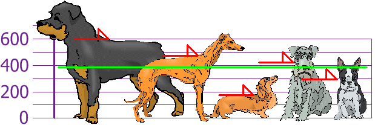

Vi har målt 5 hundes højder til 600mm, 470mm, 170mm, 430mm and 300mm.

Altså har vi et dataset $ x = [600, 470, 170, 430, 300] $

Genemnittet er $ \overline{x} = \frac{600 + 470 + 170 + 430 + 300}{5} = \frac{1970}{5} = 394 $

Vi kan nu beregne hverenkelt hunds afvigelse fra gennemsnittet:

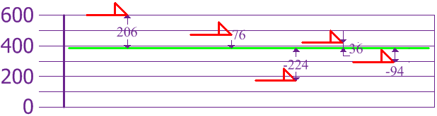

$ [(600 - 394), (470 - 394), (170 - 394), (430 - 394), (300 - 394)] = [206, 76, -224, 36, -94] $

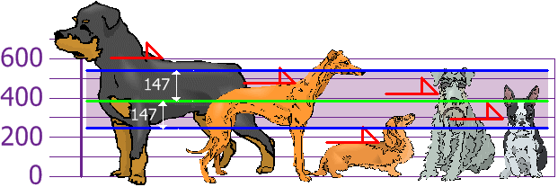

Med Standardavigelsen kan vi se hvormeget hundenes højder afviger fra gennemsnittet, og ...

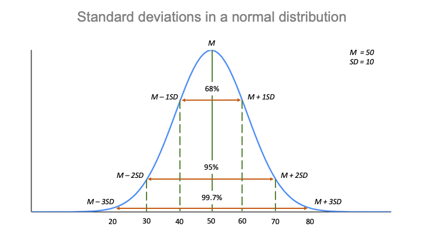

Standardafvigelsen ($ SD $) er således defineret, at hvis man tager alle tallene i listen, og udvælger dem, som er to standarsafvigelser under gennemsnittet, op til dem, som er to standard afvigelser over gennemsnittet, $$ \overline{x} - 2 \cdot SD < x_i < \overline{x} + 2 \cdot SD $$ så har man 95% af tallene, hvis tallene er normal-fordelt!